# Jeremy Mulcahey: Assignment #2

[figure not shown]

```python
from IPython.display import Image
import numpy as np
import pandas as pd
import math
import matplotlib
import matplotlib.pyplot as plt
import pylab as pl
import matplotlib.dates as mdates
import urllib2 as ul
from datetime import datetime
from pandas.stats.moments import ewma as ewma
%matplotlib inline
```

[figure not shown]

```python
#create a variable for the web address
url = 'http://hopey.netfonds.no/tradedump.php?date=20141013&paper=NFLX.O&csv_format=txt'
open('data/NFLXTicker.csv','wb').write(ul.urlopen(url).read())
```

```python
NFLXFrame = pd.read_csv('data/NFLXTicker.csv', delimiter="\t")
```

```python
#drop NaN columns
NFLXFrame.drop(['board','source','buyer','seller','initiator'], inplace = True, axis=1)
```

```python
#convert time values to a standard python format
NFLXFrame['timeConvert'] = [datetime.strptime(t, "%Y%m%dT%H%M%S") for t in NFLXFrame['time']]
NFLXFrame['xTime'] = mdates.date2num(NFLXFrame['timeConvert'])
ind = NFLXFrame['timeConvert']
price = NFLXFrame['price']
quantity = NFLXFrame['quantity']
```

```python
#inspect dataFrame
NFLXFrame.head()
```

|  | time | price | quantity | timeConvert | xTime |
| --- | --- | --- | --- | --- | --- |
| 0 | 20141013T153000 | 451.25 | 100 | 2014-10-13 15:30:00 | 735519.645833 |
| 1 | 20141013T153000 | 451.20 | 392 | 2014-10-13 15:30:00 | 735519.645833 |
| 2 | 20141013T153000 | 451.21 | 100 | 2014-10-13 15:30:00 | 735519.645833 |
| 3 | 20141013T153000 | 451.11 | 100 | 2014-10-13 15:30:00 | 735519.645833 |
| 4 | 20141013T153000 | 451.12 | 100 | 2014-10-13 15:30:00 | 735519.645833 |

```python
#export for minitab (just in case)
open('data/NFLXFrame.csv','wb').write(NFLXFrame.to_csv());
```

```python
#create a time series to slice data by time windows
NFLXTSprice = pd.Series(index = ind)
NFLXTSprice[0:] = price
NFLXTSprice.head()
```

```
timeConvert
2014-10-13 15:30:00    451.25
2014-10-13 15:30:00    451.20
2014-10-13 15:30:00    451.21
2014-10-13 15:30:00    451.11
2014-10-13 15:30:00    451.12
dtype: float64
```

```python
#create a time series to slice data by time windows
NFLXTSquant = pd.Series(index = ind)
NFLXTSquant[0:] = quantity
NFLXTSquant.head()
```

```
timeConvert
2014-10-13 15:30:00    100
2014-10-13 15:30:00    392
2014-10-13 15:30:00    100
2014-10-13 15:30:00    100
2014-10-13 15:30:00    100
dtype: int64
```

```python
#create a datetime indices for the weighted time intervals
intervals = pd.date_range('10/13/2014', periods=270, freq='5min')
intervals2 = pd.Series(intervals,index =intervals)
indexForWeights = intervals2['2014-10-13 15:30:00':'2014-10-13 22:00:00']
index = np.arange(79)
reindex = indexForWeights.reindex(index)
reindex[0:] = indexForWeights
```

```python
#function to create five minute weighted windows
def weighted_fiveMinInt(quantityTS,priceTS,tsOfIntervals):
    weights = quantityTS*priceTS
    fiveMinIntervals = np.zeros(len(tsOfIntervals)-1)
    for i in range(len(tsOfIntervals)-1):
        weightSlice = sum(weights[tsOfIntervals[i]:tsOfIntervals[i+1]])
        quantSlice = sum(quantityTS[tsOfIntervals[i]:tsOfIntervals[i+1]])
        newPrice = weightSlice/quantSlice
        fiveMinIntervals[i] = newPrice
    return fiveMinIntervals
```

```python
weightedWindows = weighted_fiveMinInt(NFLXTSquant,NFLXTSprice,reindex)
weightedWindowsTS = pd.Series(weightedWindows, index =indexForWeights[1:])
```

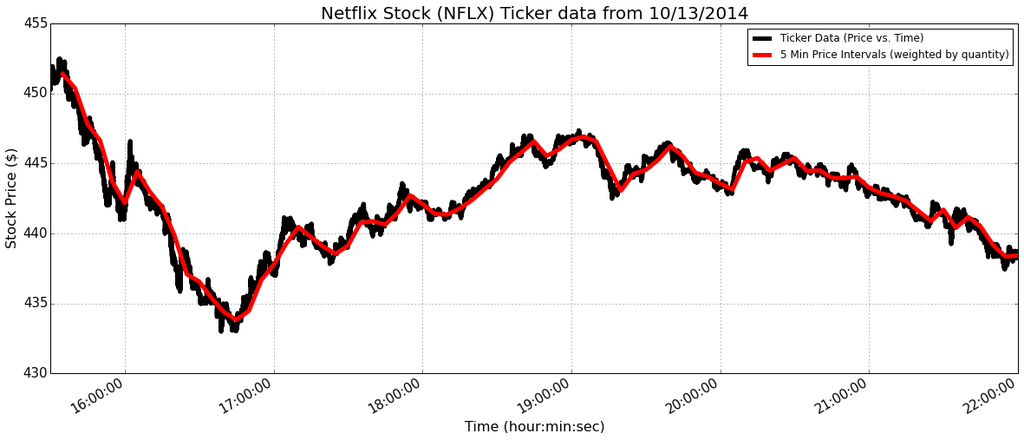

```python
#open a figure window and color it white
figure = plt.figure(figsize=(20,8))

#built-in DataFrame function to plot time as x and theta as y, with custom y limits, line width, and color
TSPlot = NFLXTSprice.plot(linewidth=5, c='black')

Line2 = weightedWindowsTS.plot(linewidth=5, c='red')

#set x and y labels, title, and adjust thier sizes according
TSPlot.set_ylabel('Stock Price ($)', fontsize=16)
TSPlot.set_xlabel('Time (hour:min:sec)',fontsize=16)
TSPlot.set_title('Netflix Stock (NFLX) Ticker data from 10/13/2014',fontsize=20)
plt.tick_params(axis='both', labelsize=15)   #change the font size of the axes ticks

TSPlot.legend(('Ticker Data (Price vs. Time)','5 Min Price Intervals (weighted by quantity)'), loc=1);
```

[figure not shown]

```python
fiveEWMA = ewma(NFLXTSprice, span=.3333)
fiftyEWMA = ewma(NFLXTSprice, span=(float(2)/51))
```

Here are the EWMA's vs. 5min window and Original data.

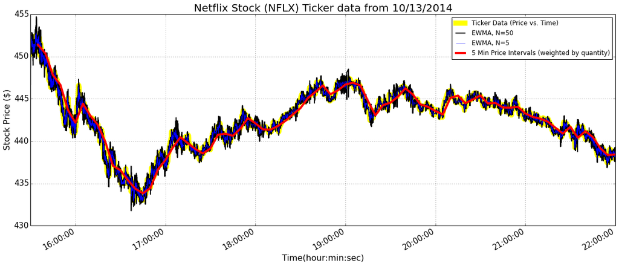

```python
#open a figure window and color it white
figure = plt.figure(figsize=(20,8))

#built-in DataFrame function to plot time as x and theta as y, with custom y limits, line width, and color
TSPlot = NFLXTSprice.plot(linewidth=10, c='yellow')

Line3 = fiftyEWMA.plot(linewidth=2, c='black')
Line4 = fiveEWMA.plot(linewidth=.5, c='blue')
Line2 = weightedWindowsTS.plot(linewidth=4, c='red')

#set x and y labels, title, and adjust thier sizes according
TSPlot.set_ylabel('Stock Price ($)', fontsize=16)
TSPlot.set_xlabel('Time(hour:min:sec)',fontsize=16)
TSPlot.set_title('Netflix Stock (NFLX) Ticker data from 10/13/2014',fontsize=20)
plt.tick_params(axis='both', labelsize=15)

TSPlot.legend(('Ticker Data (Price vs. Time)','EWMA, N=50','EWMA, N=5','5 Min Price Intervals (weighted by quantity)'), loc=1);
```

Because of how many data points we have, it's hard to really tell the differences here. We'll have to look at a smaller time window.

```python
#MAPE Function
def MAPE(obs, pred):
    return np.mean(np.abs((obs - pred) / obs)) * 100
```

Here are the EWMA's vs. 5min window.

```python
weightedfiveEWMA = ewma(weightedWindowsTS, span=.3333)
weightedfiftyEWMA = ewma(weightedWindowsTS, span=(float(2)/51))
```

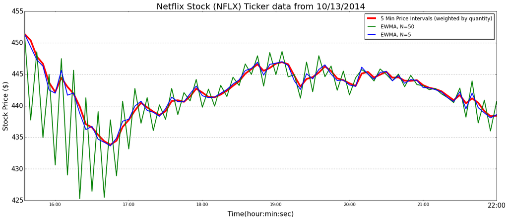

```python
#open a figure window and color it white
figure = plt.figure(figsize=(20,8))

#built-in DataFrame function to plot time as x and theta as y, with custom y limits, line width, and color
TSPlot = weightedWindowsTS.plot(linewidth=4, c='red')

Line3 = weightedfiftyEWMA.plot(linewidth=2, c='green')
Line4 = weightedfiveEWMA.plot(linewidth=2, c='blue')

#set x and y labels, title, and adjust thier sizes according
TSPlot.set_ylabel('Stock Price ($)', fontsize=16)
TSPlot.set_xlabel('Time(hour:min:sec)',fontsize=16)
TSPlot.set_title('Netflix Stock (NFLX) Ticker data from 10/13/2014',fontsize=20)
plt.tick_params(axis='both', labelsize=15)

TSPlot.legend(('5 Min Price Intervals (weighted by quantity)','EWMA, N=50','EWMA, N=5'), loc=1);
```

```python
print("MAPE of 5min intervals vs. EWMA with N=5:",MAPE(weightedWindowsTS,weightedfiveEWMA))
print("MAPE of 5min intervals vs. EWMA with N=50:",MAPE(weightedWindowsTS,weightedfiftyEWMA))
```

```
('MAPE of 5min intervals vs. EWMA with N=5:', 0.089715078179396057)
('MAPE of 5min intervals vs. EWMA with N=50:', 0.59743781232206561)
```

The plot, and the MAPE values, indicate that EWMA with N=5 is similar to the 5 minute weighted windows that I created, while EWMA with N=50 is very eradict.

[figure not shown]

In case I don't get my functions working, I used minitab to obtain the optimization value:

[figure not shown]

```python
optEwma2 = ewma(weightedWindowsTS,span=1.39925)
```

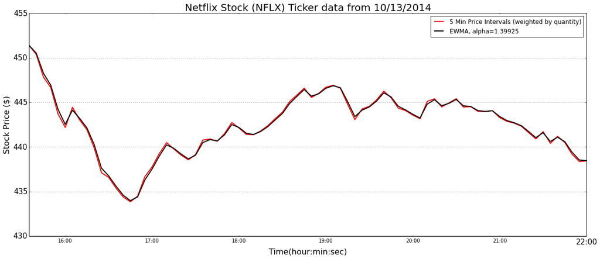

```python
#open a figure window and color it white
figure = plt.figure(figsize=(20,8))

#built-in DataFrame function to plot time as x and theta as y, with custom y limits, line width, and color
TSPlot = weightedWindowsTS.plot(linewidth=2, c='red')

Line3 = optEwma2.plot(linewidth=2, c='black')

#set x and y labels, title, and adjust thier sizes according
TSPlot.set_ylabel('Stock Price ($)', fontsize=16)
TSPlot.set_xlabel('Time(hour:min:sec)',fontsize=16)
TSPlot.set_title('Netflix Stock (NFLX) Ticker data from 10/13/2014',fontsize=20)
plt.tick_params(axis='both', labelsize=15)

TSPlot.legend(('5 Min Price Intervals (weighted by quantity)','EWMA, alpha=1.39925'), loc=1);
```

```python
print("EWMA with N=5:",MAPE(weightedWindowsTS,weightedfiveEWMA))
print("EWMA with N=50:",MAPE(weightedWindowsTS,weightedfiftyEWMA))
print("Optimized EWMA:",MAPE(weightedWindowsTS,optEwma2))
```

```
('EWMA with N=5:', 0.089715078179396057)
('EWMA with N=50:', 0.59743781232206561)
('Optimized EWMA:', 0.035841896187249533)
```

The optimized EWMA has a MAPE of .0358. The optimized EWMA appears to fit the 5 minute interval data almost perfectly, with N=5 functioning as a good approximation and N=50 not being apparently useful.

[figure not shown]

For starters, we are treating the errors in this data as iid ~N(0,simga^2).

The predicition is the last value of the first order exponential smoother (forecast origin). This is because we are treating the data as a constant process. Each subsequent prediction will also be the last value of the first order exponential smoother.

The prediciton intervals are generated by adding and subtracting a margin of error from the forcast origin, where the MOE is the product a two-sided critical z-score (alpha/2) & the estimated standard deviation of the errors.

[figure not shown]

We're still assuming that the errors are iid~N(0,sigma^2).

The predicition has changed from the previous problem because we are now accounting for a trend in the data. Adding the trend term to the smoother enables us to achieve forecast values that differ from the forecast origin. In this particular case, the negative trend in the data appears to have influenced a negative trend in the predicted values.

The predicition interval is now generated by adding the trend to the forecast origin value and then adding and subtracting the MOE. It's important to note that the trend value here is a function of the forecast step. For each step beyond the forecast origin, the trend value changes. Additionally, the MOE error term is now the product of the MOE term described in 1d and a value that grows with each forecast step. So, now the predicition intervals will adjust the trend for subsequent forecast steps and the MOE will grow indefinitely.

[figure not shown]

The optimal value is a much closer fit for the data than part a, however, these optimal values greatly change the predicition interval. The lower gammma value initially creates a smaller PI, which doesn't last since gamma grows with each forecast step. Since the prediction interval has the product of alpha^2 and gamma in the MOE, the higher alpha value from the optimization causes the prediction intervals to grow much faster.

[figure not shown]

Like the previous problems, this prediction is based on the forecast origin. In this particular forecast, we are now adding the trend and the seasonal component. Since the seasonal component is a dominant cycle observed in the data, it enables the predictions to utilize the observed cycle to make a better predicition.

The prediction intervals, from what I can tell between the book and the internet are the same as the Holt's Method PI's. The PI should continue to grow with each forecast step and larger values of gamma/alpha will cause the PI's to be wider (initially) and grow faster (than the growth observed in the data above).

[figure not shown]

There does not appear to be any autocorrelation in this scatter plot. The time at which the line crosses the mean appears to happen frequently and randomly. The concentration of points before and after the line crosses mean appear to be random as well.

[figure not shown]

This lagged scatterplot does not indicate autocorrelation (at lag 1) and has a very low r-square value (.1). This is as close to random as I have seen in a scatter plot in my Cal Poly classes.

[figure not shown]

The Durbin-Watson test looks for autocorrelation at lag one.  
Ho: No Serial Autocorrelation (at lag 1)  
Ha: Serial Autocorrelation  
According to the text, for uncorrelated values the Durbin-Watson test statistic should be approximately 2. With a Durbin-Watson test statistic of 2.06 we fail to reject the Null Hypothesis. Therefore, we have no evidence of serial autocorrelation (at one lag) in our data.

[figure not shown]

The LBQ Test looks for autocorrelation in the the lags from 1 to p. In this case, p = 75.  
Ho: No Serial Autocorrelation (from lags 1 to 75)  
Ha: Serial Autocorrelation  
With a LBQ Test statistics of 70.028 and a p-value of .6408 (using a Chi-square distribution with 75 degrees of freedom) we fail to reject the Null Hypothesis. Therefore, we have no evidence of serial autocorrelation (from lag 1 to 75) in our data.

[figure not shown]

Yes, the results were consistent. Each method indicated that there was no apparent autocorrelation at lag 1. Additionally, the correlogram and the LBQ test indicated that there was no autocorrelation at from lags 1 to 75 (with the possible exception of lag 10 in the correlogram).

[figure not shown]

There does appear to be significant autocorrelation in this time series plot. The time series line crosses the mean at regular intervals (periods) with a consistent amount of point before the line crossed the mean and after the line crosses the mean. The observable pattern is a damped sinusoid.

[figure not shown]

The circular pattern (as well as a high r-square = .7 value) in the lagged scatter plot indicates there is significant autocorrelation.

[figure not shown]

The Durbin-Watson test looks for autocorrelation at lag one.  
Ho: No Serial Autocorrelation (at lag 1)  
Ha: Serial Autocorrelation  
With a Durbin-Watson statistic of .317703, using appendix A.5 from the text, we would reject Null Hypothesis for any alpha and any sample size (in the appendix). Therefore, we have very strong evidence against no serial autocorrelation.

[figure not shown]

The LBQ Test looks for autocorrelation in the the lags from 1 to p. In this case, p = 75.  
Ho: No Serial Autocorrelation (from lags 1 to 75)  
Ha: Serial Autocorrelation  
With a LBQ Test statistics of 13019.7 and a p-value of approximately 0 (using a Chi-square distribution with 75 degrees of freedom) we reject the Null Hypothesis. Therefore, we have very strong evidence against no serial autocorrelation (from lag 1 to 75) in our data.

[figure not shown]

Using this formula in excel, r-square = .683. The MA(1) model accounts for 68.3% of the variation in detections/5seconds in our geiger counter time series.

[figure not shown]

Using the formula in excel, to estimate En (En+1 = Yn+1 - Yn(1)), the following time series with 1 step was generated.

[figure not shown]

Using the formula I stated in 5c, the plot is a shift of the MA(1) from part A.

If we increase beta to .9, we see the MA(1) model looks similar to the original geiger counter time series.

[figure not shown]

Decreasing theta (approaching 0) has the opposite effect. The MA(1) series should approach the mean as theta approaches 0.

[figure not shown]